# Mistakes I made

Erin Bennett

10/3/2018

## Log-normal Density function

I am a silly person.

The Log-normal cdf evaluated at $x$ is the same as the Normal cdf evaluated at $log(x)$. But the *density* function for Log-normal is *not* the same as the desnity function for Normal evaluated at $log(x)$.

The density function is the derivative of the cdf. So the chain rule applies.

$$f(x) = \frac{d}{dx}\Phi(\log(x)) = \Phi'(\log(x)) \cdot \frac{d}{dx}\log(x) = \varphi(\log(x)) \cdot \frac{d}{dx}\log(x)$$

Spelling this out even further, for any given change in $x$, there’s a corresponding change in $log(x)$. If the Log-normal density were just the Normal density of the log, then the probability *mass* corresponding to a given change in $x$ would be different than the probability mass for that *same* change in $log(x)$. And that is not how things work. Here’s the correct (black) and incorrect (red) density functions (rescaled so their max density is the same, so we can see them both):

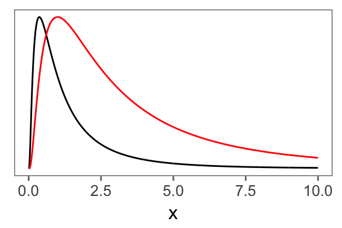

So, given the params $\mu$ and $\sigma$ (in log space) of the Log-normal distribution, the density function would be:

$$\varphi\left(\frac{\log(x) - \mu}{\sigma}\right)\frac{1}{\sigma x}$$

or

$$\frac{1}{x} \cdot \frac{1}{\sigma\sqrt{2\pi}} \cdot \exp\left(-\frac{(\log(x) - \mu)^2}{2\sigma^2}\right)$$
And so the score is

$$\begin{aligned}
\log\left( \frac{1}{x} \cdot \frac{1}{\sigma\sqrt{2\pi}} \exp\left(-\frac{(\log(x) - \mu)^2}{2\sigma^2}\right) \right) &=
\log(\frac{1}{x}) + \log(\frac{1}{\sigma\sqrt{2\pi}}) -\frac{(\log(x) - \mu)^2}{2\sigma^2} = \\
&= -\log(x) - \log(\sigma) - \frac{1}{2}\log((2\pi)) - \frac{(\log(x) - \mu)^2}{2\sigma^2}
\end{aligned}$$

## `cache` $\neq$ `mem`

[doh.](https://webppl.readthedocs.io/en/master/functions/other.html#cache)

Caching is correct for functions that return ERPs.

There’s a different cache for each call to `cache`, it’s not like a global thing or something.

## binning

I had this notion that it was possible and worth trying to compute S1 analytically.

$$\begin{aligned}
L_0(x | \text{expensive}, \theta) =&
\begin{cases}
\frac{1}{1 - CDF(\theta)}P(x) & \text{if } x>\theta \\
0 & \text{otherwise}
\end{cases} \\
\\
L_0(x | \text{no utt}, \theta) &= P(x)
\end{aligned}$$

The utility for the speaker is the log of the density for $L_0$.

$$\begin{aligned}
S_1(u | x, \theta)
\propto& \ e^{ \left(
U(u ; x, \theta) - C(u)
\right)} \\
=& \ e^ { \left(
\alpha_1\log\left(L_0(x | u, \theta)\right) - C(u)
\right)} \\
=& \ e^{\alpha_1\log(L_0(x|u, \theta))} \cdot e^{-C(u)} \\
=& \left(L_0(x | u, \theta)\right)^{\alpha_1}P(u)
\end{aligned}$$

If $x \leq \theta$, then $S_1$ will choose “no utterance” with probability 1. Otherwise:

$$\begin{aligned}
S_1(u | x, \theta) \propto& P(u)L_1(x | u, \theta) \\
\\
S_1(u | x, \theta) =&
\frac{
P(u)\left(L_1(x | u, \theta)\right)^{\alpha_1}
}{
P(\text{expensive})\left(L_1(x | \text{expensive}, \theta)\right)^{\alpha_1} + P(\text{no utt})\left(L_1(x | \text{no utt}, \theta)\right)^{\alpha_1}
} \\ \\ \\
=&
\frac{P(u)
\left(
\left.\begin{cases}
\left(1 - CDF(\theta)\right)^{\alpha_1} & \text{if } u= \text{ ``expensive''} \\
1 & \text{otherwise}
\end{cases}\right\}
\right)^{-\alpha_1}
}{
P(\text{expensive})\frac{1}{\left(1 - CDF(\theta)\right)^{\alpha_1}} + P(\text{no utt})
}
\end{aligned}$$

Then we would use the log of this analytic function inside the factor statement for $L1$. ($L_1$ would choose an $x$ and $\theta$ with high $S_1$ informativity.)

Now the question is, is it faster to get a good estimate of $L1$ for each utterance using MCMC, or is it faster to deterministically compute a discrete version of $L_1$ and $S_2$ with bins that work for our epsilons?

The simplest way to bin that would work for our purposes would be to choose the smallest epsilon and the largest price in the experiment and the cutoffs would be `seq(0, max_value, smallest_eps)`.

| object | smallest_eps | largest_price | bins |
| --- | --- | --- | --- |
| coffee maker | 0.22 | 350 | 1591 |
| headphones | 0.31 | 450 | 1452 |
| laptop | 3.00 | 3450 | 1150 |
| sweater | 0.15 | 300 | 2000 |
| watch | 0.15 | 3350 | 22334 |

We could use a different binning scheme for each epsilon.

```
// gradually coarsening as you get away from the region you're currently considering
var make_bins = function(price, eps){
  [
  price - eps,
  price,
  price + eps,
  price + 2*eps,
  price + 4*eps,
  price + 8*eps,
  price + 32*eps,
  ...,
  ]
}


var speaker2 = mem(function(epsilon) {
  return Infer({method: "enumerate"}, function() {
    var L1 = listener1("expensive");
    var price = sample(L1);
    var price_eps = price + eps;
    var new_bins = make_bins(price, eps)
    var L1_i = listener1("expensive", new_bins);
    factor(alpha * L1_i.score(price_eps))
    return utterance;
  })
});
```

helpful links from MH: * https://github.com/mhtess/generic-interpretation/blob/master/models/node_modules/utils/utils.wppl * https://github.com/mhtess/generic-interpretation/blob/master/models/node_modules/utils/utils.js